# Figure S2: Motifs enriched in top CBP, ATAC and DV transcription factor peaks

**Project:** Enhancer identification

**Author:** Jeff Johnston

**Generated:** Mon Aug 22 2016, 04:08 PM

## Define peaks and controls

For each of the peak lists below, we select the top 500 non-TSS peaks by Peakzilla or MACS2 (for ATAC) score and compare them to all remaining non-TSS peaks.

| factor_name | peaks | control_peaks |
| --- | --- | --- |
| Twist | 500 | 9296 |
| Mad | 500 | 6394 |
| Zen | 500 | 8757 |
| Dorsal | 500 | 3719 |
| CBP | 500 | 7109 |
| ATAC | 500 | 15993 |

## Assign FlyBase gene IDs to known motifs

## Calculate enrichments

We can now test for enrichment of known motifs using each set of transcription factor peaks and corresponding control regions. We will use an adjusted p-value cutoff of 0.05. All peaks have been resized to 201 bp centered on the peak summit.

We do not test the following motifs:

- All JASPAR_CORE motifs, as they are duplicates of JASPAR_2014
- All daughterless (da) hetereodimer motifs
- All motifs where the corresponding transcription factor is not expressed in any of the two tissues (FPKM > 5)

This results in 358 tested motifs.

After removal, we calculate an adjusted p-value for each motif enrichment test.

## Calculate overlap values for pairs of significant motifs

We next calculate the overlap between all pairs of 96 significant motifs.

## Enrichment and overlap heat maps

Motif overlap table

| keep_motif | other_names |
| --- | --- |
| FlyFactorSurvey-Aef1_SANGER_5_FBgn0005694 | FlyFactorSurvey-CG11504_SANGER_5_FBgn0039733 FlyFactorSurvey-CG4360_F1.3_SANGER_2.5_FBgn0038787 FlyFactorSurvey-slp1_NAR_FBgn0003430 JASPAR_2014-slp1-MA0458.1 FlyFactorSurvey-Aef1_FlyReg_FBgn0005694 |
| FlyFactorSurvey-bcd_FlyReg_FBgn0000166 | FlyFactorSurvey-Oc_SOLEXA_FBgn0004102 |
| FlyFactorSurvey-Blimp.1_NAR_FBgn0035625 | FlyFactorSurvey-Blimp.1_SANGER_5_FBgn0035625 |
| FlyFactorSurvey-CG12155_SANGER_5_FBgn0029957 | FlyFactorSurvey-CG12155_SANGER_5_FBgn0029957 |
| FlyFactorSurvey-CG14962_SANGER_5_FBgn0035407 | FlyFactorSurvey-CG14962_SANGER_5_FBgn0035407 |
| FlyFactorSurvey-CG16778_SANGER_5_FBgn0003715 | FlyFactorSurvey-tai_SANGER_5_FBgn0041092 FlyFactorSurvey-twi_FlyReg_FBgn0003900 JASPAR_2014-twi-MA0249.1 |
| FlyFactorSurvey-CG5669_SOLEXA_5_FBgn0039169 | JASPAR_2014-btd-MA0443.1 FlyFactorSurvey-btd_NAR_FBgn0000233 FlyFactorSurvey-CG3065_F1.3_SOLEXA_2.5_FBgn0034946 FlyFactorSurvey-CG3065_F1.5_SOLEXA_2.5_FBgn0034946 |
| FlyFactorSurvey-CG5953_SANGER_5_FBgn0032587 | FlyFactorSurvey-CG5953_SANGER_5_FBgn0032587 |
| FlyFactorSurvey-crp_SANGER_10_FBgn0001994 | FlyFactorSurvey-crp_SANGER_10_FBgn0001994 |
| FlyFactorSurvey-Dfd_SOLEXA_FBgn0000439 | FlyFactorSurvey-Eve_Cell_FBgn0000606 FlyFactorSurvey-Ftz_Cell_FBgn0001077 FlyFactorSurvey-tup_SOLEXA_10_FBgn0003896 FlyFactorSurvey-zen2_SOLEXA_2_FBgn0004054 FlyFactorSurvey-Zen2_SOLEXA_FBgn0004054 Fl… |
| FlyFactorSurvey-dl_NBT_FBgn0000462 | FlyFactorSurvey-lola.PC_SANGER_5_FBgn0005630 FlyFactorSurvey-Rel_SANGER_5_FBgn0014018 FlyFactorSurvey-shn.F1.2_SANGER_5_FBgn0003396 JASPAR_2014-dl_1-MA0022.1 JASPAR_2014-dl_2-MA0023.1 FlyFactorSurvey-… |
| FlyFactorSurvey-Ems_Cell_FBgn0000576 | FlyFactorSurvey-Ems_Cell_FBgn0000576 |
| FlyFactorSurvey-Espl_FlyReg_FBgn0000591 | FlyFactorSurvey-Espl_FlyReg_FBgn0000591 |
| FlyFactorSurvey-exd_FlyReg_FBgn0000611 | FlyFactorSurvey-exd_FlyReg_FBgn0000611 |
| FlyFactorSurvey-ftz.f1_SANGER_5_FBgn0001078 | FlyFactorSurvey-ftz.f1_SANGER_5_FBgn0001078 |
| FlyFactorSurvey-Med_FlyReg_FBgn0011655 | FlyFactorSurvey-Med_FlyReg_FBgn0011655 |
| FlyFactorSurvey-NFAT_SANGER_5_FBgn0030505 | FlyFactorSurvey-NFAT_SANGER_5_FBgn0030505 |
| FlyFactorSurvey-ovo_SOLEXA_5_FBgn0003028 | FlyFactorSurvey-ovo_SOLEXA_5_FBgn0003028 |
| FlyFactorSurvey-pho_SANGER_10_FBgn0002521 | FlyFactorSurvey-pho_SOLEXA_5_FBgn0002521 FlyFactorSurvey-pho_FlyReg_FBgn0002521 FlyFactorSurvey-phol_SOLEXA_5_FBgn0035997 |
| FlyFactorSurvey-run_Bgb_NBT_FBgn0003300 | FlyFactorSurvey-run_Bgb_NBT_FBgn0013753 |
| FlyFactorSurvey-sna_FlyReg_FBgn0003448 | FlyFactorSurvey-sna_SANGER_10_FBgn0003448 FlyFactorSurvey-CG17181_SOLEXA_5_FBgn0035144 |
| FlyFactorSurvey-Sox14_SANGER_10_FBgn0005612 | FlyFactorSurvey-Sox14_SANGER_10_FBgn0005612 |
| FlyFactorSurvey-Trl_FlyReg_FBgn0013263 | JASPAR_2014-Trl-MA0205.1 FlyFactorSurvey-CG10904_SANGER_5_FBgn0034945 |
| FlyFactorSurvey-ttk_FlyReg_FBgn0003870 | FlyFactorSurvey-ttk_NAR_FBgn0003870 FlyFactorSurvey-ttk.PF_SANGER_5_FBgn0003870 JASPAR_2014-ttk-MA0460.1 |
| FlyFactorSurvey-vfl_SANGER_5_FBgn0259789 | FlyFactorSurvey-vfl_SOLEXA_5_FBgn0259789 FlyFactorSurvey-CG17181_SANGER_5_FBgn0035144 |
| FlyFactorSurvey-z_FlyReg_FBgn0004050 | JASPAR_2014-z-MA0255.1 |
| JASPAR_2014-Abd-B-MA0165.1 | FlyFactorSurvey-AbdB_Cell_FBgn0000015 |
| JASPAR_2014-CTCF-MA0531.1 | FlyFactorSurvey-brk_FlyReg_FBgn0024250 FlyFactorSurvey-lola.PL_SANGER_2.5_FBgn0005630 FlyFactorSurvey-phol_SANGER_5_FBgn0035997 JASPAR_2014-brk-MA0213.1 |
| JASPAR_2014-hb-MA0049.1 | FlyFactorSurvey-AbdB_SOLEXA_FBgn0000015 FlyFactorSurvey-hb_FlyReg_FBgn0001180 FlyFactorSurvey-hb_NAR_FBgn0001180 FlyFactorSurvey-hb_SANGER_2.5_FBgn0001180 FlyFactorSurvey-hb_SOLEXA_5_FBgn0001180 FlyFa… |
| JASPAR_2014-Mad-MA0535.1 | FlyFactorSurvey-Mad_FlyReg_FBgn0011648 |
| JASPAR_2014-Su(H)-MA0085.1 | JASPAR_2014-Su(H)-MA0085.1 |

Motif pairs with more than 10% overlapping instances are combined, selecting the motif with the best p-value.

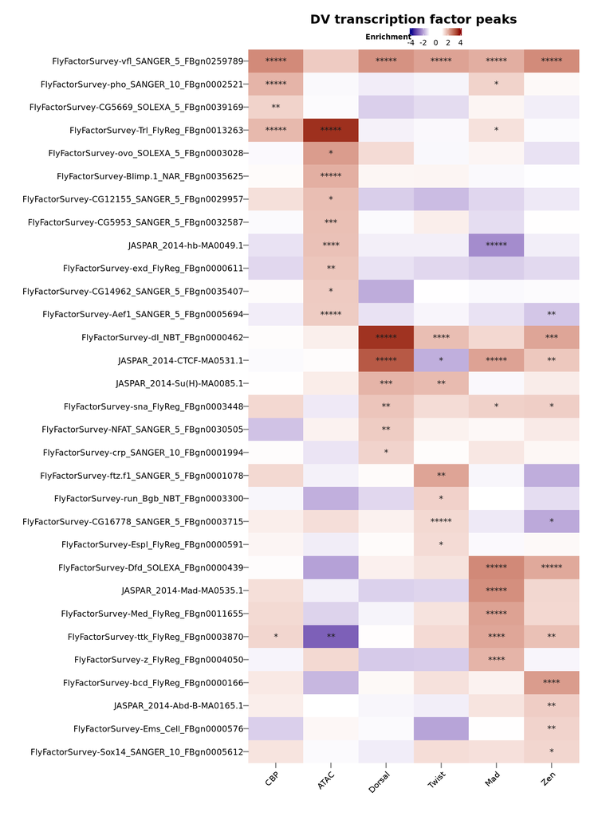

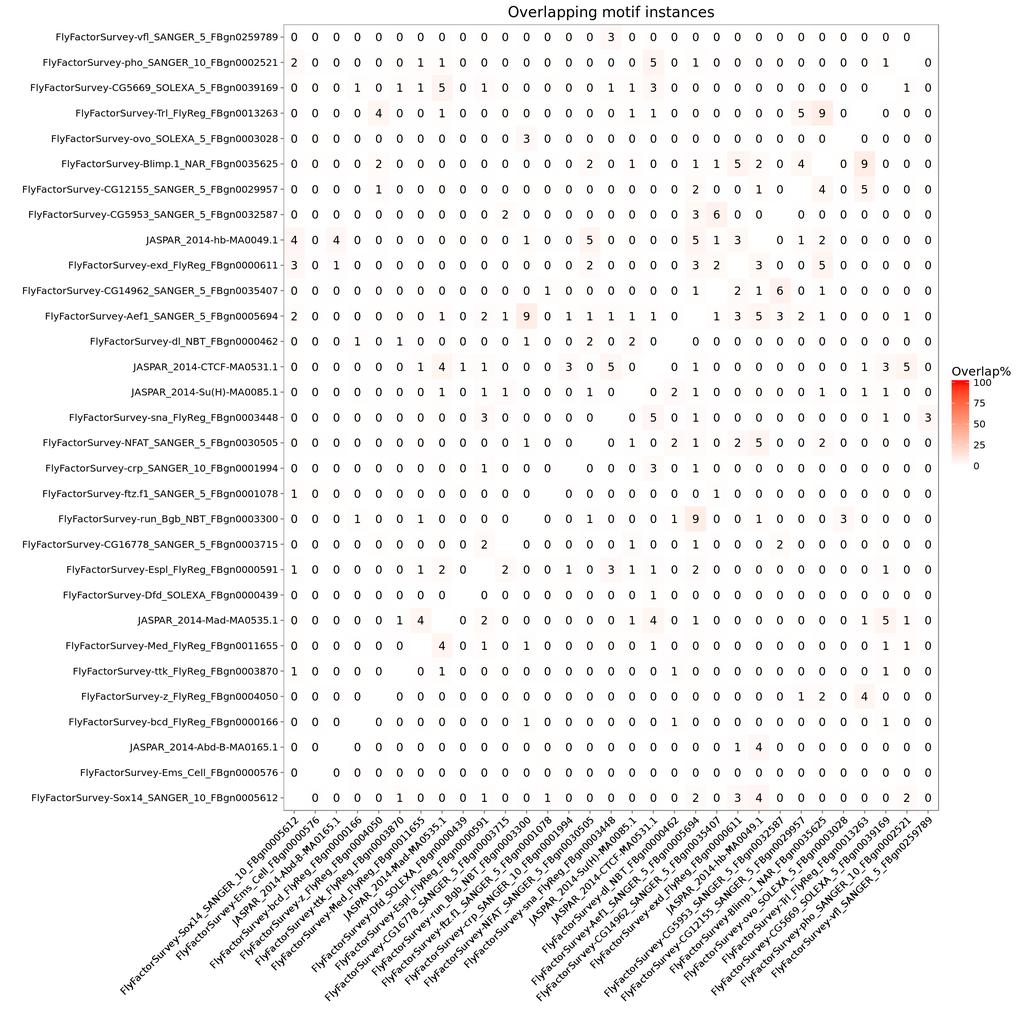